# Clustering for Quakes Data Set

# Gap statistics

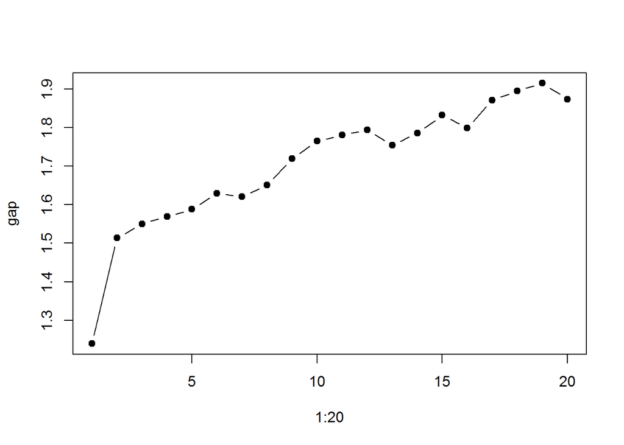

```r
gapstat <- function(m, k, N=20){
w=numeric(N)
x=numeric(20)

for (i in 1:N)
{
  m.new = apply(scale(m),2,function(x){
    runif(length(x),min=min(x),max=max(x))
  })
  kf = kmeans(m.new,k)
  w[i] = kf$tot.withinss
}
return(list(LW=mean(log(w)),SE=sd(log(w))/sqrt(N)))
}

calcgap <- function(dataset){

gap = numeric(20)
se = numeric(20)
for(k in 1:20){
  kf = kmeans(scale(dataset),k)
  sim = gapstat(scale(dataset),k)
  gap[k]=sim$LW-log(kf$tot.withinss)
  se[k]=sim$SE
}
plot(1:20,gap,pch=19,type="b")

}

calcgap(whsAnnBdatNum)
```

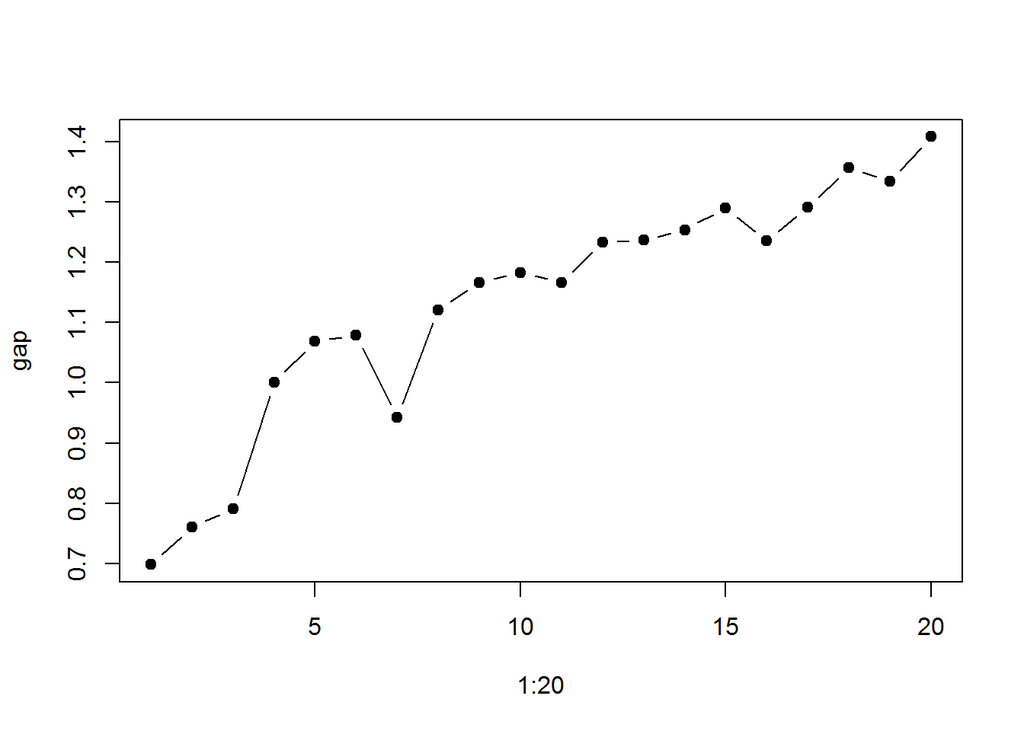

```r
calcgap(quakes)
```

# Stability of hierarchical clustering

```r
matrix.sort <- function(m){
  require(clue)
  p=solve_LSAP(m,maximum=T)
  m[,p]
}
cmp.shortcut = function(K,DS){
whs = dist(scale(DS))
hc=hclust(whs,method="ward.D2")
clustcut <- cutree(hc,K)
  matrix.sort(table(
              km=kmeans(scale(DS),K,20)$cluster,
              hc=clustcut))
}
cmp.shortcut(2,whsAnnBdatNum)
```

```
##    hc
## km    2   1
##   1 131   4
##   2   8  51
```

```r
cmp.shortcut(3,whsAnnBdatNum)
```

```
##    hc
## km   3  1  2
##   1 36  0 15
##   2  0 49  4
##   3  1  6 83
```

```r
cmp.shortcut(4,whsAnnBdatNum)
```

```
##    hc
## km   3  4  1  2
##   1 34  0  5  1
##   2  0 37  0 54
##   3  0  0 15 20
##   4  0  0  1 27
```

```r
cmp.shortcut(2,quakes)
```

```
##    hc
## km    1   2
##   1 204   0
##   2 184 612
```

```r
cmp.shortcut(3,quakes)
```

```
##    hc
## km    3   1   2
##   1 175  16   0
##   2   3 178  14
##   3   2  14 598
```

```r
cmp.shortcut(4,quakes)
```

```
##    hc
## km    4   3   2   1
##   1 169   0   0  11
##   2   1 265  15  22
##   3   7   4 328  21
##   4   3   0   0 154
```

## Between/within variance in hierarchical clusters

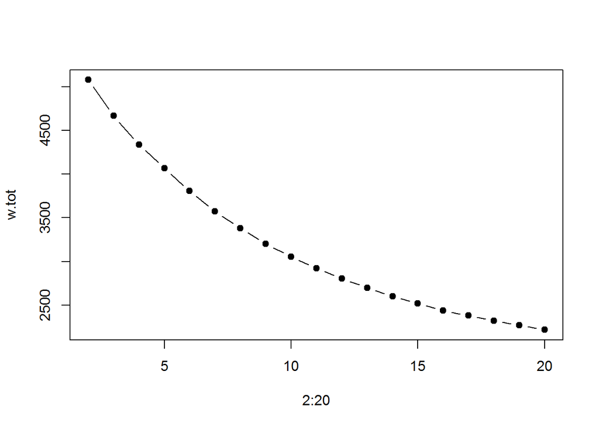

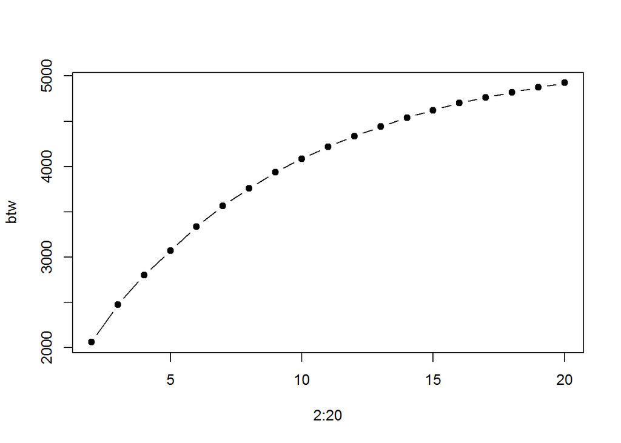

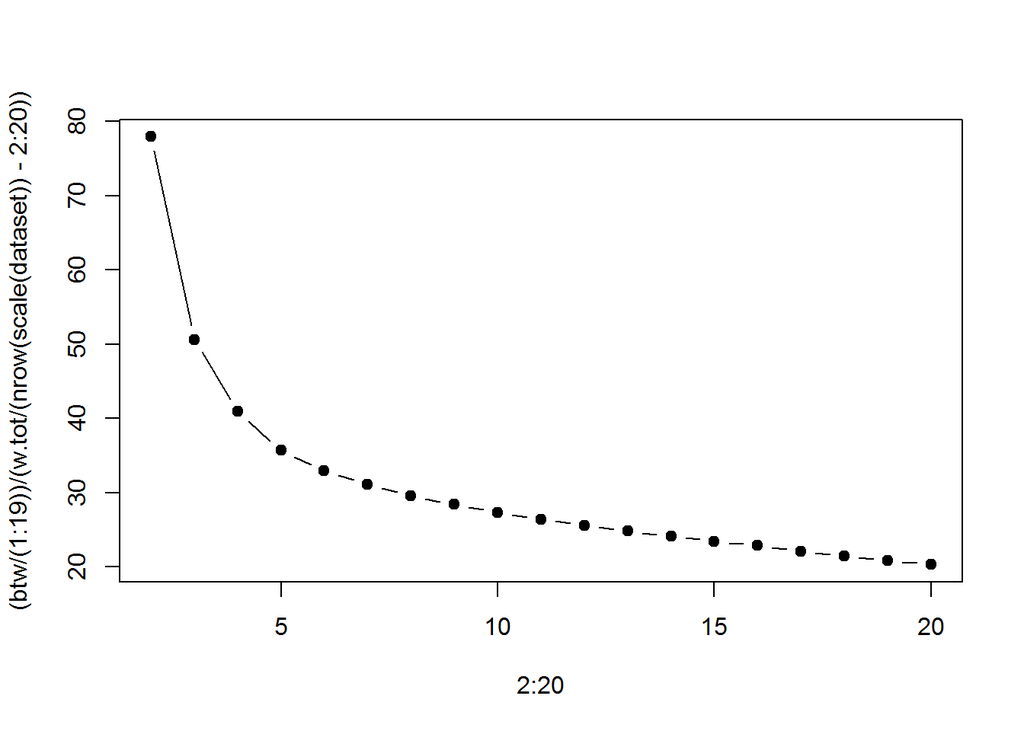

```r
within = function(d, clust){
  w = numeric(length(unique(clust)))
  for(i in sort(unique(clust))){
    members = d[clust ==i, , drop=F]
    centroid = apply(members,2,mean)
    members.diff = sweep(members,2,centroid)
    w[i]= sum(members.diff^2)
  }
  return(w)
}

between = function(d,clust){
  b=0
  total.mean=apply(d,2,mean)
  for(i in sort(unique(clust))){
    members=d[clust==i,,drop=F]
    centroid=apply(members,2,mean)
    b=b+nrow(members)*sum((centroid-total.mean)^2)
  }
  return(b)
}

between_within <- function(dataset){

dd = dist(scale(dataset))
hw = hclust(dd,method="ward.D2")
w.tot = numeric(19)
btw = numeric(19)
for(k in 2:20){
  clust = cutree(hw,k=k)
  w = within(scale(dataset),clust)
  w.tot[k-1]=sum(w)
  btw[k-1]=between(scale(dataset),clust)
}
plot(2:20,w.tot,pch=19,type="b")
plot(2:20,btw,pch=19,type="b")
plot(2:20,(btw/(1:19))/(w.tot/(nrow(scale(dataset))-2:20)),pch=19,type="b")
}

between_within(whsAnnBdatNum)
```

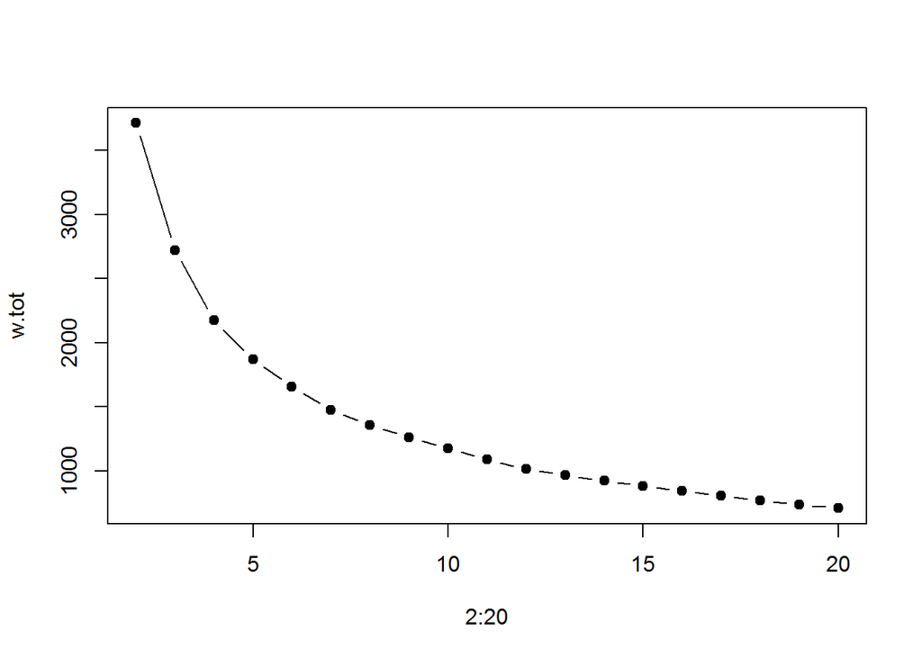

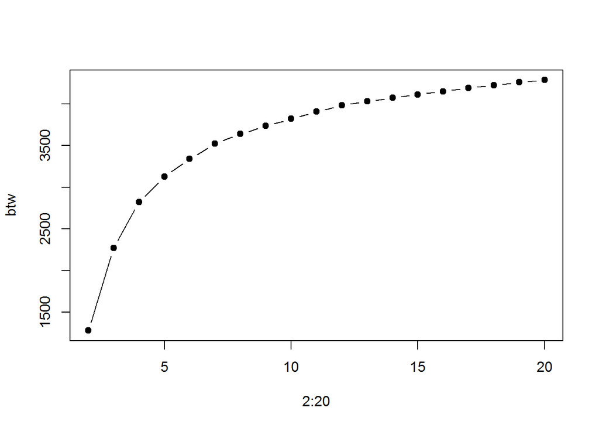

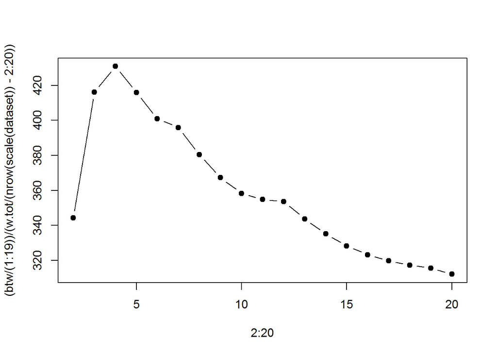

```r
between_within(quakes)
```

The shape of the curve obtained using the above method for total distance and between cluster distance is similar to the one obtained in problem 2 . The peak in ratio of between the clusters and total distance is clearly visible in quakes data set at 4 clusters where as the ratio keeps reducing with peak at 2 clusters. Which is not good indication of identifying clusters.